# PCA and Clustering for Log Data

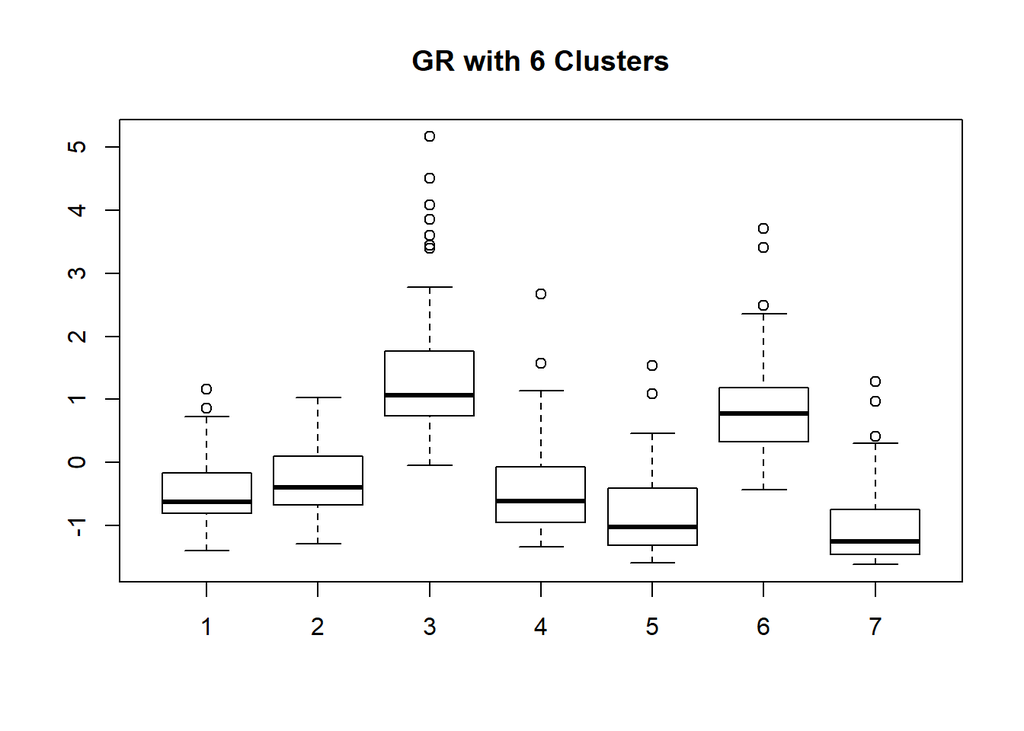

```r
boxplot(dta$GR~km.out6$cluster, main="GR with 6 Clusters")
```

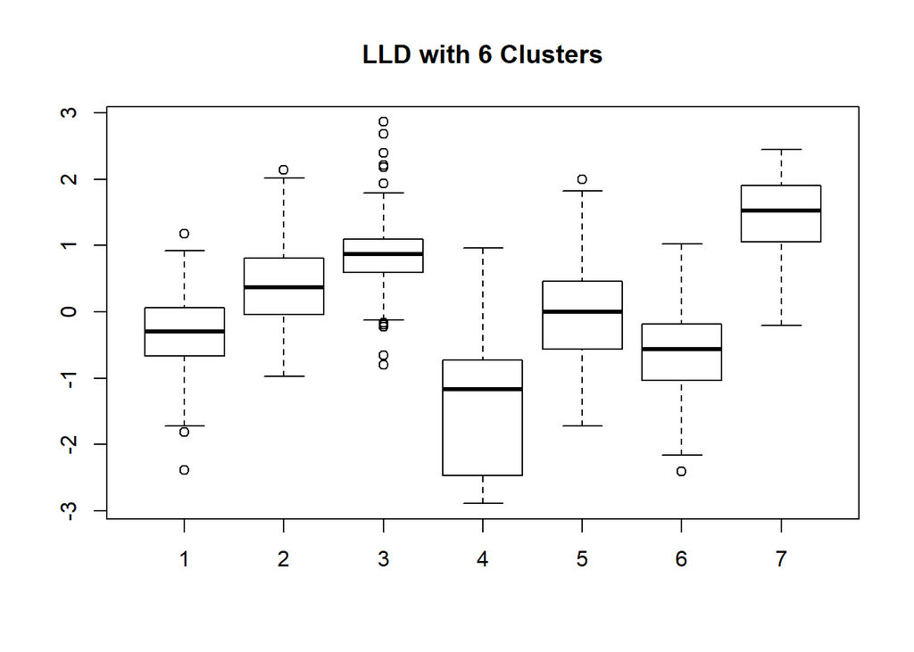

```r
boxplot(dta$log10.LLD.~km.out6$cluster, main="LLD with 6 Clusters")
```

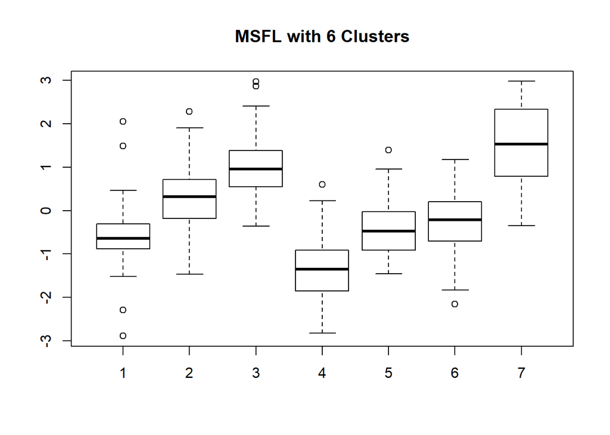

```r
boxplot(dta$log10.MSFL.~km.out6$cluster, main="MSFL with 6 Clusters")
```

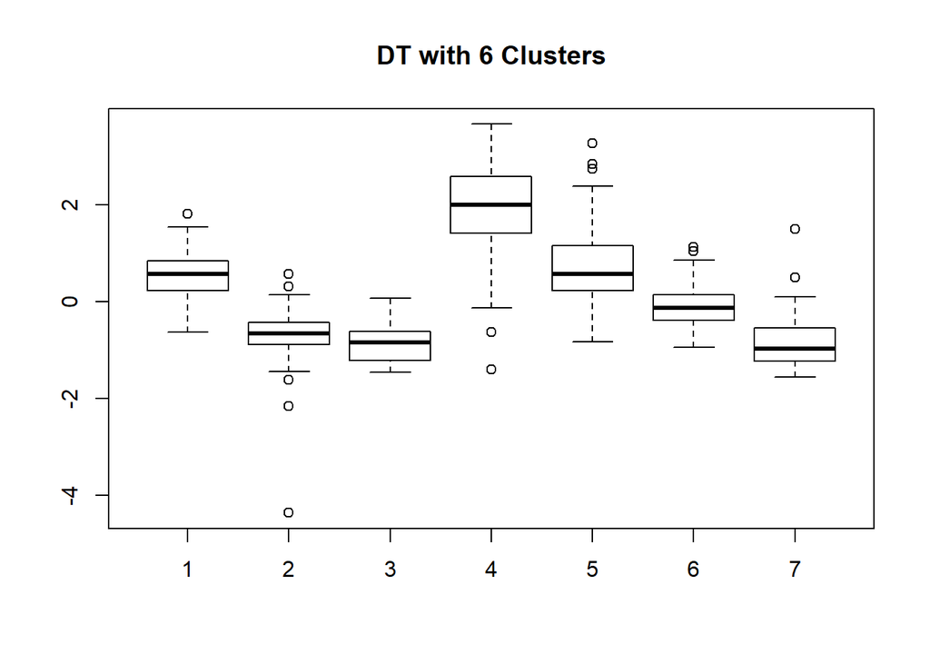

```r
boxplot(dta$DT~km.out6$cluster, main="DT with 6 Clusters")
```

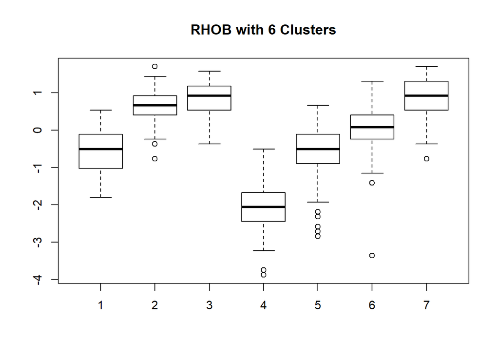

```r
boxplot(dta$RHOB~km.out6$cluster, main="RHOB with 6 Clusters")
```

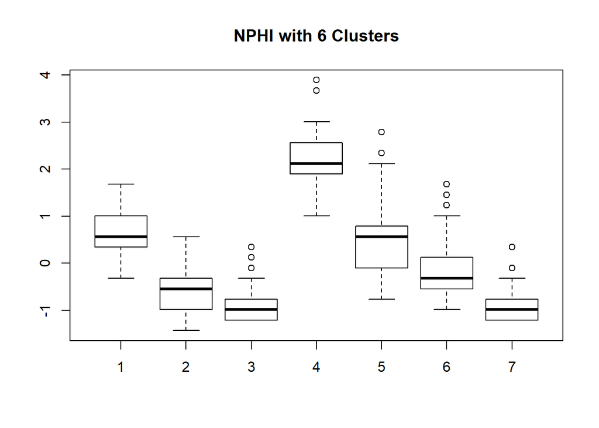

```r
boxplot(dta$NPHI~km.out6$cluster, main="NPHI with 6 Clusters")
```

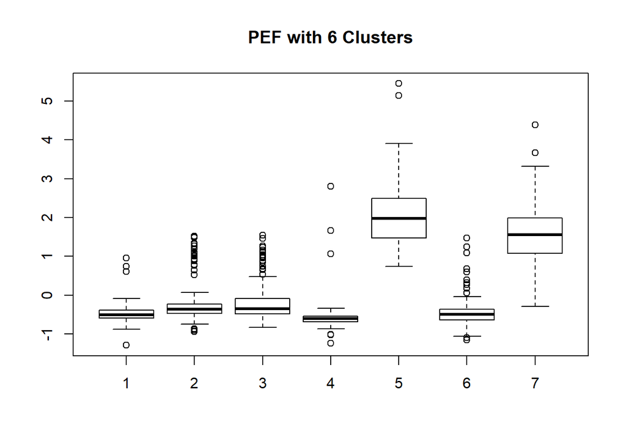

```r
boxplot(dta$PEF~km.out6$cluster, main="PEF with 6 Clusters")
```

```r
jpeg('clusters.jpg')
par(mfrow=c(1,3))
plot(pca$x[,1:2], col=(km.out4$cluster+1), main="4 Clusters", pch=20, cex=2)
plot(pca$x[,1:2], col=(km.out5$cluster+1), main="5 Clusters", pch=20, cex=2)
plot(pca$x[,1:2], col=(km.out6$cluster+1), main="6 Clusters", pch=20, cex=2)
dev.off()
```

### Boxplots for Variables for Each Clusters

Boxplots of the logs are used to determine the appropriate number of clusters. The log interpretations are done qualitatively, and further analysis is needed to quantify the parameters, for example, porosity and saturation. In the end, consulting the results with geoscientists will be a good idea to do.

```r
jpeg('GRPEF.jpg')
par(mfrow=c(2,3))
boxplot(dta$GR~km.out4$cluster, main="GR with 4 Clusters")
boxplot(dta$GR~km.out5$cluster, main="GR with 5 Clusters")
boxplot(dta$GR~km.out6$cluster, main="GR with 6 Clusters")
boxplot(dta$PEF~km.out4$cluster, main="PEF with 4 Clusters")
boxplot(dta$PEF~km.out5$cluster, main="PEF with 5 Clusters")
boxplot(dta$PEF~km.out6$cluster, main="PEF with 6 Clusters")
dev.off()
```

```r
jpeg('porosity.jpg')
par(mfrow=c(3,3))
boxplot(dta$DT~km.out4$cluster, main="DT with 4 Clusters")
boxplot(dta$DT~km.out5$cluster, main="DT with 5 Clusters")
boxplot(dta$DT~km.out6$cluster, main="DT with 6 Clusters")
boxplot(dta$NPHI~km.out4$cluster, main="NPHI with 4 Clusters")
boxplot(dta$NPHI~km.out5$cluster, main="NPHI with 5 Clusters")
boxplot(dta$NPHI~km.out6$cluster, main="NPHI with 6 Clusters")
boxplot(dta$RHOB~km.out4$cluster, main="RHOB with 4 Clusters")
boxplot(dta$RHOB~km.out5$cluster, main="RHOB with 5 Clusters")
boxplot(dta$RHOB~km.out6$cluster, main="RHOB with 6 Clusters")
dev.off()
```

```r
jpeg('resistivity.jpg')
par(mfrow=c(2,3))
boxplot(dta$log10.LLD.~km.out4$cluster, main="LLD with 4 Clusters")
boxplot(dta$log10.LLD.~km.out5$cluster, main="LLD with 5 Clusters")
boxplot(dta$log10.LLD.~km.out6$cluster, main="LLD with 6 Clusters")
boxplot(dta$log10.MSFL.~km.out4$cluster, main="MSFL with 4 Clusters")
boxplot(dta$log10.MSFL.~km.out5$cluster, main="MSFL with 5 Clusters")
boxplot(dta$log10.MSFL.~km.out6$cluster, main="MSFL with 6 Clusters")
dev.off()
```

## Summary

1. 4 Principal components (PC) are used in the clustering analysis, since 4 PCs explain 90% of the total variance.
2. K-Mean clustering algorithm is used to divide the observations into clusters, and each clustering algorithm is repeated 100 times to find the global minimum.
3. Comparing 4,5, and 6 clusters qualitatively, the most appropriate number of clusters is 5, since it differentiate between sand and shale, and that there is no significant difference between 5 and 6 clusters.
4. The best clusters are cluster 1 and 5, which are sandstone with medium porosity, medium resistivity, and limestone with medium porosity, medium resistivity respectively. The analysis is done qualitatively and quantitative calculation (porosity, saturation) needs to be done with addition to discussion with geoscientists.